# Coursework Report

*N* removed NAs: 4

*N* removed <18: 19

**Correct typo age:** 21

*N* total clean: 145

| Group | *N* | *M*<sub>age</sub> | % green |
| --- | --- | --- | --- |
| Control | 75 | 20.8 | 50.7 |
| Experim | 70 | 20.8 | 30.9 |

| Gender | *N* | *M*<sub>age</sub> | % green |
| --- | --- | --- | --- |
| Female | 67 | 21.0 | 42.3 |
| Male | 53 | 20.7 | 43.4 |
| Other | 25 | 20.4 | 33.3 |

**Main analysis results**

**cleaner:**  
χ<sup>2</sup>(1) = 3.66, *p* = .056

**dishwasher:**  
χ<sup>2</sup>(1) = 6.61, *p* = .010

[interactive chart not shown]

[figure not shown]

[interactive chart not shown]

# Coursework Report

Analysing Data, Spring 2020

# Methods

## Participants

Table 1. Descriptive Statistics per Condition

[output not shown]

Table 2. Decsriptve Statistics by Gender

[output not shown]

## Design

The main research question for this replication study is focused on “Why do people purchase pro-environmental “green” products?” and investigating the idea of buying “green” products to be altruistic. Specifically examining how activating a motive for status had an impact on the participants choice between the two selections of luxury “non-green” products and non-luxury “green” products. The dependent variable was the choice of green products and non-green luxurious products. Non-green products that were selected scored higher on dimensions of luxury and performance whereas green products, on the dimension of pro-environmental benefits were superior. The contrasting products were equally priced and manufactured by the same company, with the non-green products specifically picked to seem more desirable than green counterparts and the green products; a car; a cleaner; and a dishwasher, were chosen as they came in pro-environmental options and non-pro-environmental options; with each advertising different environmental benefits; lower CO2 emissions, being non-toxic and water efficiency. The study was conducted with two between-subjects’ story conditions, our independent variable. The controlstory condition in which the participants read the control story and the status motives experimental story condition in which the participants read the status motives story. In both conditions, participants were required to read a short story that elicited status motives. The control condition detail a story on losing a concert ticket and retrieving it as used by Griskevicius, Cialdini, & Kenrick (2006); Griskevicius, Goldstein, Mortensen, Cialdini, & Kenrick,(2006) and the status condition detailed a story of a first day on a new job, focused on the high-status feature within the workplace such as the décor, the story ends with the reader learning of a new promotion and them pondering on moving up in status. The story successfully elicits status motives shown by Griskevicius, Tybur, et al, (2009) and a desire for social status and prestige and includes no mention of pro-environmental behaviour. It was predicted that the status motives would encourage people to want to be perceived as more prosocial, with the 3 green products regarded as being more prosocial than the non-green/luxury products. Thus, the non-green products will be chosen more frequently within the control condition and activating status motives will lead people to pick the prosocial green products rather than the luxurious non-green products and to test this hypothesis, a chi-squared statistical test will be administered.

# Results

Table 3. Expected Frequency of Car Variable by Condition

|  | luxury | green |
| --- | --- | --- |
| control | 38.5 | 35.5 |
| experimental | 36.5 | 33.5 |

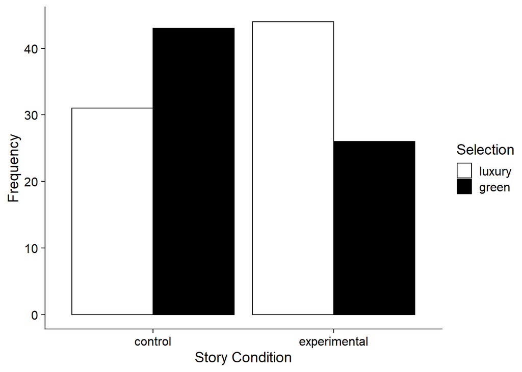

```
##               SELECTION
## CONDITION      luxury green
##   control          31    43
##   experimental     44    26
```

Table 4. Expected Frequency of Dishwasher Variable by Condition

|  | luxury | green |
| --- | --- | --- |
| control | 46 | 29 |
| experimental | 43 | 27 |

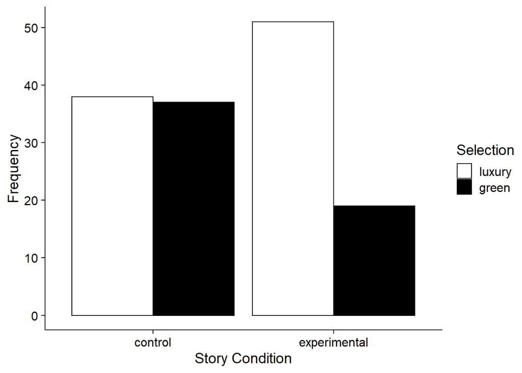

```
##               SELECTION
## CONDITION      luxury green
##   control          38    37
##   experimental     51    19
```

Table 5. Expected Frequency of Cleaner Variable by Condition

|  | luxury | green |
| --- | --- | --- |
| control | 47.1 | 27.9 |
| experimental | 43.9 | 26.1 |

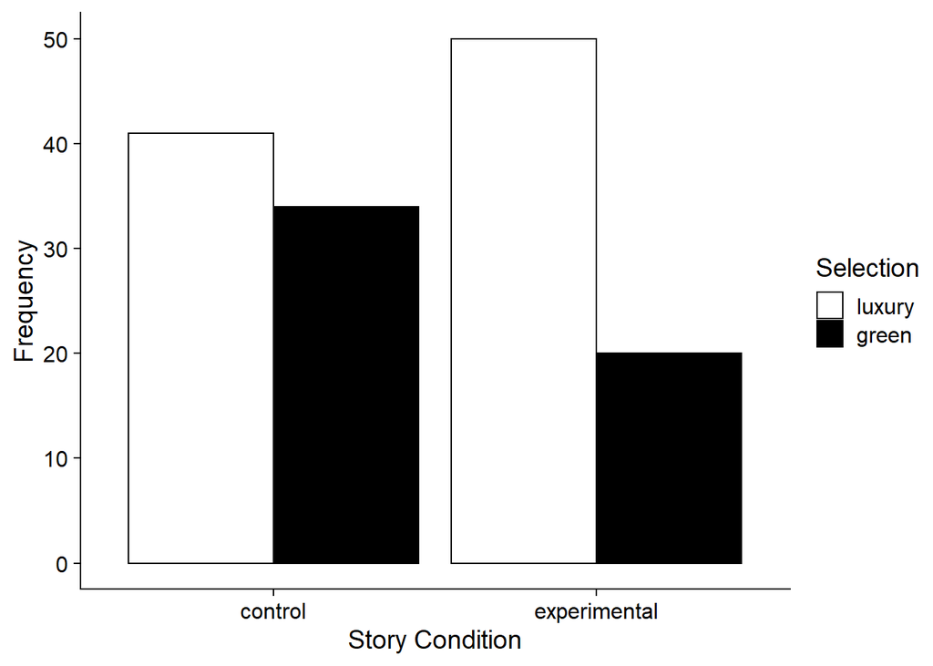

```
##               SELECTION
## CONDITION      luxury green
##   control          41    34
##   experimental     50    20
```

# Discussion

This replication aimed to look at the research question “Why do people purchase pro-environmental “green” products?”, specifically, is it related to being perceived as prosocial and a desire for status?. Our findings were significant for 2 products; dishwasher, and car, although our bar graphs indicate that status in fact has increased the likelihood of people choosing the luxury product contrary to my hypothesis, we could determine that our results in fact support that status motives increase the likelihood of participants choosing a luxury product. This result indicates that buying green products may not be influenced by a desire for prestige and appearing prosocial to peers. The study by Griskevicius, Tybur, & Bergh, (2010) of which this replication is based upon, indicate in their results that activating status motives in contrast increased prosocial behaviour and more participants chose the green products. As the two study results are not cohesive with one another, we could suggest that there may be another variable unaccounted for that has affected the outcome, for instance individual differences between participants can influence their choices as for each participant, status may be achieved in varying ways depending on what is valued locally to them. Therefore, despite theories of status being a key aspect of consumer behaviour (Griskevicius & Kenrick, 2013), it is important to note that individual differences between desire for status are affected by many features, such as culture (Huberman, Loch and Önçüler, 2004), gender (Hays, 2013), even political ideology (Kennedy and Horne, 2019) and that the desire for status although seemingly universal (Anderson, Hildreth and Howland (2015) is altered depending on individual circumstance and knowledge as well as what is locally valued by their peers, this could be an interesting avenue for future research to investigate. A limitation of the current replication research is that the experiment did not involve participants actively buying any products which could have impacted participants behaviour, but instead was focused on the context of buying such products and the effects in terms of status, therefore this would be an interesting endeavour for future research to investigate how status motives influence real purchasing behaviours, this would improve the ecological validity of any findings. However, a strength of this replication is that it involved a much larger sample of the original study thereby allows us to investigate the effects found by Griskevicius, Tybur, and Bergh, (2010) on a larger scale and as our results showed, it seems the effects of status motives has less impact on green, prosocial consumer behaviours than originally found. It would be beneficial for future research to question how pro-environmental behaviours are perceived by others, as this would help advertisers and even activists understand how to better present a “green” message to the public by understanding their attitudes towards it. This replication, the original study and others included in this research area are more vital than ever, as we collectively begin to understand more the impact our actions and behaviours can have upon the planet and what we can do to combat the issue that is global warming and prolong our species and our planet’s longevity.

# References

Anderson, C., Hildreth, J. A. D., & Howland, L. (2015, March 16). Is the Desire for Status a Fundamental Human Motive? A Review of the Empirical Literature. Psychological Bulletin. Advance online publication. http://dx.doi.org/10.1037/a0038781

Griskevicius, V., Cialdini, R. B., & Kenrick, D. T. (2006). Peacocks, Picasso, and parental investment: The effects of romantic motives on creativity. Journal of Personality and Social Psychology, 91, 63–76.

Griskevicius, V., Goldstein, N. J., Mortensen, C. R., Cialdini, R. B., & Kenrick, D. T. (2006). Going along versus going alone: When fundamental motives facilitate strategic (non)conformity. Journal of Personality and Social Psychology, 91, 281–294

Griskevicius, V., Tybur, J. M., Gangestad, S. W., Perea, E. F., Shapiro, J. R., & Kenrick, D. T. (2009). Aggress to impress: Hostility as an evolved context-dependent strategy. Journal of Personality and Social Psychology, 96, 980–994.

Griskevicius, V., Tybur, J. M., &:Bergh, B. V. (2010). Going green to be seen: Status, reputation, and conspicuous conservation. Journal of Personality and Social Psychology, 98(3), 392-404. doi:10.1037/a0017346

Griskevicius, V., & ; Kenrick, D. T. (2013). Fundamental motives: How evolutionary needs influence consumer behavior. Journal of Consumer Psychology, 23(3), 372-386. doi:10.1016/j.jcps.2013.03.003

Hays, N. A. (2013). Fear and loving in social hierarchy: Sex differences in preferences for power versus status. Journal of Experimental Social Psychology, 49, 1130 –1136. http://dx.doi.org/10.1016/j.jesp.2013.08 .007

Huberman, B. A., Loch, C. H., & Önçüler, A. (2004). Status as a valued resource. Social Psychology Quarterly, 67, 103–114. http://dx.doi.org/10.1177/019027250406700109

Kennedy, E. H., &; Horne, C. (2019). Do Green Behaviors Earn Social Status? Socius: Sociological Research for a Dynamic World, 5, 237802311983633. doi:10.1177/2378023119836330